# Fish Screening Exploration - K3RP Keno Reach

Badhia Yunes Katz

August 2025

## 1. Background

This explores two GIS layers from the **Klamath Reservoir Reach Restoration Prioritization (K3RP)** fish screening prioritization: diversions **downstream of Keno Dam** (`K3RP_FinalScreening_DSofKENO`) and diversions **upstream of Keno Dam** (`K3RP_FinalScreening_USofKENO`, in the Lake Ewauna / Keno reach).

Per *Appendix C: Fish Screening Project Descriptions*, diversions were evaluated for fish-screening prioritization if they fell within 400 ft of expected anadromous fish distribution (a buffer meant to absorb small location inaccuracies in the underlying data). Each diversion was scored on:

- **Size score** - size of the diversion relative to the stream it draws from
- **Benefit score** - number of fish species (anadromous + resident native) affected
- **Fish impact score** (downstream reach only) - best-professional-judgment impact rating from ODFW fish biologists
- **Total score** - combination of the above, used to assign a **Priority Tier** (Low / Medium / High)

Each diversion also has a `Screen` status (`yes` / `no` / `unknown` / `no diversion`) describing whether it is already fish-screened. Water right data attached to each point is explicitly flagged in the report as **approximate and potentially inaccurate** - it should be verified before any project scoping or design work.

The source files are ArcGIS Pro **layer packages** (`.lpkx`), which are 7-zip archives bundling a shapefile plus layer symbology. We extract the shapefile out of each package before reading it with `sf`.

## 2. Load the data

```r
lpkx_dir <- here::here("data-raw", "data-exploration", "screening-keno")

extract_lpkx_layer <- function(lpkx_name) {
  lpkx_path <- file.path(lpkx_dir, lpkx_name)
  out_dir <- file.path(tempdir(), tools::file_path_sans_ext(lpkx_name))
  archive_extract(lpkx_path, dir = out_dir)

  shp <- list.files(out_dir, pattern = "\\.shp$", recursive = TRUE, full.names = TRUE)
  st_read(shp[1], quiet = TRUE)
}

screen_ds <- extract_lpkx_layer("K3RP_FinalScreening_DSofKENO.lpkx") |> clean_names()
screen_us <- extract_lpkx_layer("K3RP_FinalScreening_USofKENO.lpkx") |> clean_names()
```

## 3. Structure

Downstream-of-Keno layer:

```r
dim(screen_ds)
```

```
## [1] 26 20
```

```r
glimpse(screen_ds)
```

```
## Rows: 26
## Columns: 20
## $ pod_displa <chr> "Cert:739 OR * IR", "Cert:8118 OR * FI", "Cert:48027 OR * I…
## $ wris_link  <chr> "http://apps.wrd.state.or.us/apps/wr/wrinfo/wr_details.aspx…
## $ name_last  <chr> "FRAIN", NA, NA, NA, NA, NA, "SIMMERS", "ANDERSON", "JAMES"…
## $ name_first <chr> "W", NA, NA, NA, NA, NA, "HAROLD", "KENNETH", "LARRY ORVILL…
## $ rate_cfs   <dbl> 0.630, 3.000, 0.150, 0.100, 1.820, 9.000, 0.100, 0.240, 0.2…
## $ pod_id     <dbl> 0, 0, 0, 0, 0, 0, 0, 0, 0, 0, 0, 0, 0, 0, 0, 45424, 16441, …
## $ source_nam <chr> "KLAMATH RIVER/SPR", "SPENCER CREEK", "SPENCER CREEK", "HAY…
## $ last_name  <chr> NA, NA, NA, NA, NA, NA, NA, NA, NA, NA, NA, NA, NA, NA, NA,…
## $ notes      <chr> "IRRIGATION", "FISH CULTURE", "INDUSTRIAL/MANUFACTURING USE…
## $ state      <chr> "OR", "OR", "OR", "OR", "OR", "OR", "OR", "OR", "OR", "OR",…
## $ screen     <chr> "unknown", "no diversion", "no", "no diversion", "no", "unk…
## $ size_score <dbl> 1, 0, 1, 0, 1, 5, 1, 1, 1, 1, 0, 1, 5, 5, 2, 4, 2, 5, 4, 5,…
## $ ben_score  <dbl> 5, 0, 5, 0, 5, 5, 5, 5, 5, 5, 0, 5, 5, 5, 5, 5, 5, 5, 5, 5,…
## $ tot_score  <dbl> 1.8, 0.0, 1.8, 0.0, 4.2, 2.6, 1.8, 2.7, 2.7, 4.2, 0.0, 1.8,…
## $ co_survey  <chr> "n/a", "n/a", "n/a", "n/a", "associated with 25 (Hayden Cre…
## $ proj_num   <chr> "KL-7", "SP-1", "SP-5", "HA-2", "KL-5", "SP-6", "SP-2", "SP…
## $ stream_grp <chr> "Klamath River", "Spencer Creek", "Spencer Creek", "Hayden …
## $ pri_div    <chr> "Low", "Low", "Low", "Low", "High", "High", "Low", "Low", "…
## $ impact_sco <dbl> 1.0, 0.0, 1.0, 0.0, 5.0, 1.0, 1.0, 2.5, 2.5, 5.0, 0.0, 1.0,…
## $ geometry   <POINT [foot]> POINT (880562.9 115464.7), POINT (898070.7 151591.…
```

```r
st_crs(screen_ds)$input
```

```
## [1] "NAD83 / Oregon GIC Lambert (ft)"
```

```r
st_bbox(screen_ds)
```

```
##      xmin      ymin      xmax      ymax
## 805601.55  82281.79 898070.72 193308.84
```

Upstream-of-Keno layer:

```r
dim(screen_us)
```

```
## [1] 65 26
```

```r
glimpse(screen_us)
```

```
## Rows: 65
## Columns: 26
## $ id         <int> 0, 0, 0, 0, 0, 0, 0, 0, 0, 0, 0, 0, 0, 0, 0, 0, 0, 0, 0, 0,…
## $ notes      <chr> NA, "18\" headgate set back about 50' from river at end of …
## $ total_cfs  <dbl> 0.11, 2.34, 1903.00, 1.77, 1.02, 9.00, 31.15, 1.56, 0.00, 2…
## $ screen     <chr> "unknown", "no", "no", "unknown", "no", "no", "yes", "no di…
## $ size_score <dbl> 1, 1, 5, 1, 1, 2, 4, 0, 0, 1, 0, 1, 0, 0, 4, 0, 1, 1, 1, 5,…
## $ ben_score  <dbl> 4, 4, 4, 4, 4, 4, 4, 0, 0, 4, 0, 4, 0, 0, 4, 0, 4, 4, 4, 4,…
## $ tot_score  <dbl> 2.5, 2.5, 4.5, 2.5, 2.5, 3.0, 4.0, 0.0, 0.0, 2.5, 0.0, 2.5,…
## $ lat        <dbl> 42.21908, 42.18085, 42.17882, 42.17481, 42.17374, 42.16982,…
## $ long       <dbl> -121.7889, -121.7885, -121.7917, -121.7983, -121.7987, -121…
## $ proj_num   <chr> "KENO-1", "KENO-3", "KENO-5", "KENO-7", "KENO-9", "KENO-11"…
## $ proj_label <dbl> 1, 3, 5, 7, 9, 11, 13, 15, 17, 19, 21, 23, 25, 27, 29, 31, …
## $ wr_1       <chr> "CERT 67078  0.11 CFS", "KA 194  2.34 CFS  Griffith IR", "l…
## $ wr_2       <chr> "n/a", "n/a", "KA 312  383.6 CFS  USFWS", "n/a", "n/a", "n/…
## $ wr_3       <chr> "n/a", "n/a", "KA 318 100.4 CFS  USFW", "n/a", "n/a", "n/a"…
## $ wr_4       <chr> "n/a", "n/a", "KA 316  0.6 CFS  USFW", "n/a", "n/a", "n/a",…
## $ wr_5       <chr> "n/a", "n/a", "KA 315 9.0 CFS  USFW", "n/a", "n/a", "n/a", …
## $ wr_6       <chr> "n/a", "n/a", "KA 313  284.4 CFS  USFW", "n/a", "n/a", "n/a…
## $ wr_7       <chr> "n/a", "n/a", "KA 319  10.0 CFS  USFW", "n/a", "n/a", "n/a"…
## $ wr_8       <chr> "n/a", "n/a", "KA 1000 0.5 CFS Griffith HG", "n/a", "n/a", …
## $ wr_9       <chr> "n/a", "n/a", "KA 1000  650 CFS KID/TID", "n/a", "n/a", "n/…
## $ wr_10      <chr> "n/a", "n/a", "KA 1000   100 CFS  KID/TID drain1", "n/a", "…
## $ wr_11      <chr> "n/a", "n/a", "KA 1000  105 CFS Miller Hill PP", "n/a", "n/…
## $ wr_12      <chr> "n/a", "n/a", "KA 1000 KID PP 1-10 total 10 CFS", "n/a", "n…
## $ wr_13      <chr> "n/a", "n/a", "KA 317  249.5 CFS  USFW", "n/a", "n/a", "n/a…
## $ wr_14      <chr> "n/a", "n/a", "n/a", "n/a", "n/a", "n/a", "n/a", "n/a", "n/…
## $ geometry   <POINT [m]> POINT (599953.9 4674810), POINT (600053.1 4670566), P…
```

```r
st_crs(screen_us)$input
```

```
## [1] "NAD83 / UTM zone 10N"
```

```r
st_bbox(screen_us)
```

```
##      xmin      ymin      xmax      ymax
##  588265.4 4659729.3  600302.7 4674809.9
```

The two layers were digitized separately and don’t share a schema or a coordinate system:

- `screen_ds` carries stream/project metadata (`stream_grp`, `proj_num`, `pri_div`, `source_nam`, water-right holder fields) and is projected in **NAD83 / Oregon GIC Lambert (ft)**.
- `screen_us` carries up to 14 stacked water-right columns (`wr_1`…`wr_14`) plus its own `lat`/`long` fields, and is projected in **NAD83 / UTM zone 10N**.

```r
setdiff(names(screen_ds), names(screen_us))
```

```
##  [1] "pod_displa" "wris_link"  "name_last"  "name_first" "rate_cfs"
##  [6] "pod_id"     "source_nam" "last_name"  "state"      "co_survey"
## [11] "stream_grp" "pri_div"    "impact_sco"
```

```r
setdiff(names(screen_us), names(screen_ds))
```

```
##  [1] "id"         "total_cfs"  "lat"        "long"       "proj_label"
##  [6] "wr_1"       "wr_2"       "wr_3"       "wr_4"       "wr_5"
## [11] "wr_6"       "wr_7"       "wr_8"       "wr_9"       "wr_10"
## [16] "wr_11"      "wr_12"      "wr_13"      "wr_14"
```

## 4. Missingness

```r
map_dbl(st_drop_geometry(screen_ds), \(x) mean(is.na(x))) |>
  enframe(name = "field", value = "pct_na") |>
  arrange(desc(pct_na)) |>
  datatable(caption = "DS of Keno - % missing by field") |>
  formatPercentage("pct_na", 1)
```

|  | field | pct_na |
| --- | --- | --- |
| 1 | name_last | 0.8076923076923077 |
| 2 | name_first | 0.8076923076923077 |
| 3 | last_name | 0.5769230769230769 |
| 4 | pod_displa | 0.4230769230769231 |
| 5 | wris_link | 0.4230769230769231 |
| 6 | rate_cfs | 0 |
| 7 | pod_id | 0 |
| 8 | source_nam | 0 |
| 9 | notes | 0 |
| 10 | state | 0 |

[output cut: 9 more lines]

```r
map_dbl(st_drop_geometry(screen_us), \(x) mean(is.na(x))) |>
  enframe(name = "field", value = "pct_na") |>
  arrange(desc(pct_na)) |>
  datatable(caption = "US of Keno - % missing by field") |>
  formatPercentage("pct_na", 1)
```

|  | field | pct_na |
| --- | --- | --- |
| 1 | notes | 0.01538461538461539 |
| 2 | id | 0 |
| 3 | total_cfs | 0 |
| 4 | screen | 0 |
| 5 | size_score | 0 |
| 6 | ben_score | 0 |
| 7 | tot_score | 0 |
| 8 | lat | 0 |
| 9 | long | 0 |
| 10 | proj_num | 0 |

[output cut: 15 more lines]

## 5. Screening status

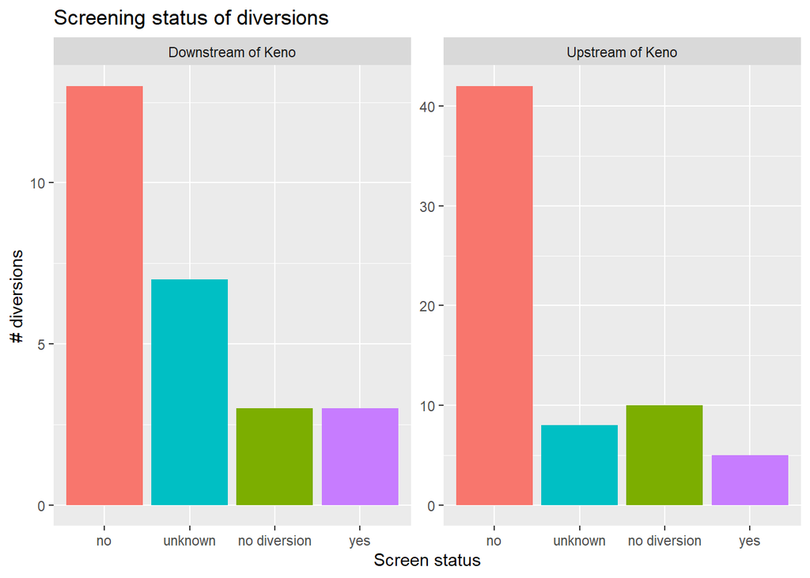

```r
screen_ds |>
  st_drop_geometry() |>
  count(screen, sort = TRUE) |>
  mutate(reach = "Downstream of Keno") |>
  bind_rows(
    screen_us |>
      st_drop_geometry() |>
      count(screen, sort = TRUE) |>
      mutate(reach = "Upstream of Keno")
  ) |>
  ggplot(aes(x = fct_infreq(screen, w = n), y = n, fill = screen)) +
  geom_col() +
  facet_wrap(~reach, scales = "free_y") +
  labs(title = "Screening status of diversions", x = "Screen status", y = "# diversions") +
  theme(legend.position = "none")
```

## 6. Score distributions

`size_score`, `ben_score`, and `tot_score` are common to both layers; `impact_sco` (fish impact) is only recorded downstream of Keno.

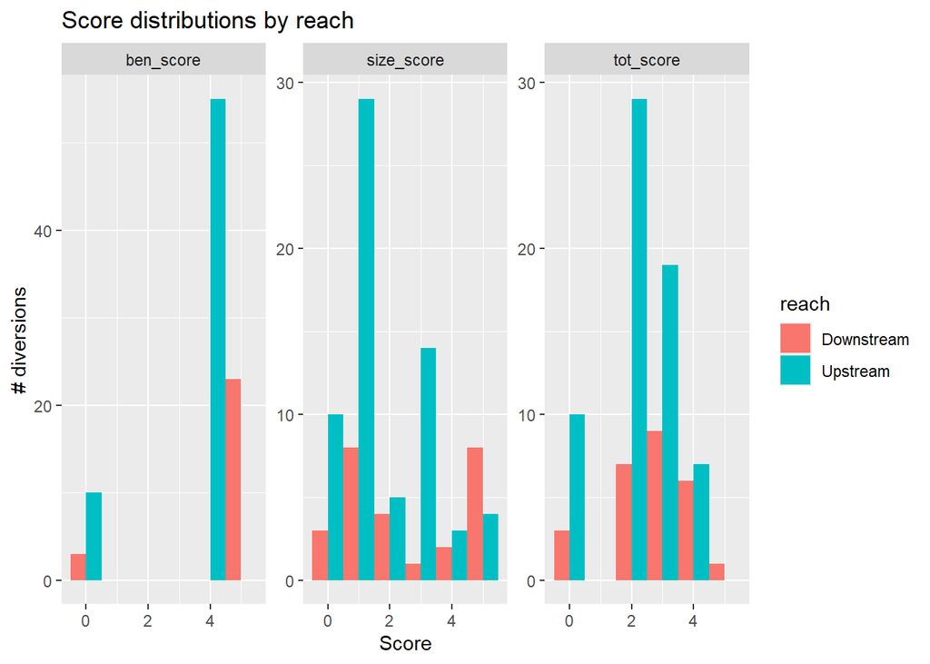

```r
bind_rows(
  screen_ds |> st_drop_geometry() |> select(size_score, ben_score, tot_score) |> mutate(reach = "Downstream"),
  screen_us |> st_drop_geometry() |> select(size_score, ben_score, tot_score) |> mutate(reach = "Upstream")
) |>
  pivot_longer(-reach, names_to = "metric", values_to = "score") |>
  ggplot(aes(x = score, fill = reach)) +
  geom_histogram(binwidth = 1, position = "dodge") +
  facet_wrap(~metric, scales = "free") +
  labs(title = "Score distributions by reach", x = "Score", y = "# diversions")
```

Downstream priority tier (`pri_div`) vs. total score - a sanity check that higher scores map to higher tiers:

```r
screen_ds |>
  st_drop_geometry() |>
  count(pri_div, sort = TRUE)
```

```
##   pri_div  n
## 1    High 16
## 2     Low 10
```

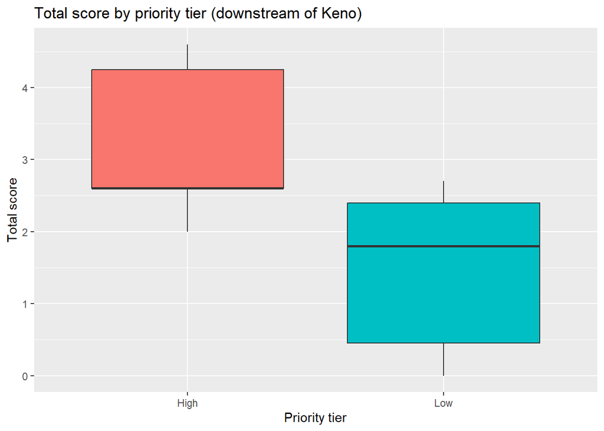

```r
screen_ds |>
  st_drop_geometry() |>
  ggplot(aes(x = pri_div, y = tot_score, fill = pri_div)) +
  geom_boxplot() +
  labs(title = "Total score by priority tier (downstream of Keno)", x = "Priority tier", y = "Total score") +
  theme(legend.position = "none")
```

## 7. Diversions by stream (downstream of Keno)

```r
screen_ds |>
  st_drop_geometry() |>
  count(stream_grp, sort = TRUE) |>
  datatable(caption = "Diversions per stream group - downstream of Keno")
```

|  | stream_grp | n |
| --- | --- | --- |
| 1 | Spencer Creek | 9 |
| 2 | Klamath River | 8 |
| 3 | Fall Creek | 4 |
| 4 | Shovel Creek | 3 |
| 5 | Hayden Creek | 2 |

## 8. Diversion size (approximate flow rate)

```r
screen_ds |>
  st_drop_geometry() |>
  summarise(min = min(rate_cfs, na.rm = TRUE), median = median(rate_cfs, na.rm = TRUE),
            max = max(rate_cfs, na.rm = TRUE))
```

```
##   min median max
## 1   0  1.665  18
```

```r
screen_us |>
  st_drop_geometry() |>
  summarise(min = min(total_cfs, na.rm = TRUE), median = median(total_cfs, na.rm = TRUE),
            max = max(total_cfs, na.rm = TRUE))
```

```
##   min median  max
## 1   0   4.11 1903
```

Flow rates span several orders of magnitude (small stockwater/domestic pumps up to large canals like the Lost River Diversion Ditch and Ady Canal), so a log scale is more useful for comparison:

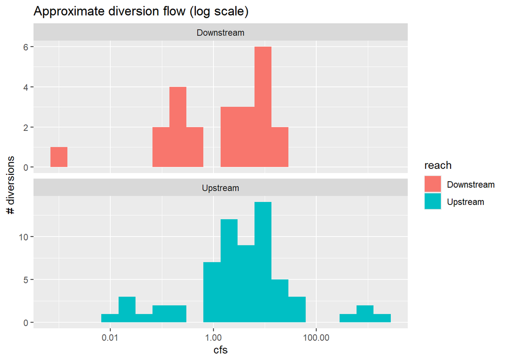

```r
bind_rows(
  screen_ds |> st_drop_geometry() |> transmute(reach = "Downstream", cfs = rate_cfs),
  screen_us |> st_drop_geometry() |> transmute(reach = "Upstream", cfs = total_cfs)
) |>
  filter(cfs > 0) |>
  ggplot(aes(x = cfs, fill = reach)) +
  geom_histogram(bins = 20) +
  scale_x_log10(labels = comma) +
  facet_wrap(~reach, ncol = 1, scales = "free_y") +
  labs(title = "Approximate diversion flow (log scale)", x = "cfs", y = "# diversions")
```

## 9. Map

Reproject both layers to WGS84 so they can share a single leaflet map.

```r
ds_wgs84 <- st_transform(screen_ds, 4326)
us_wgs84 <- st_transform(screen_us, 4326)

pal_ds <- colorFactor(c("Low" = "#2ca25f", "Medium" = "#feb24c", "High" = "#de2d26"),
                       domain = c("Low", "Medium", "High"))

leaflet() |>
  addTiles() |>
  addCircleMarkers(
    data = ds_wgs84, color = ~pal_ds(pri_div), radius = 6, stroke = FALSE, fillOpacity = 0.85,
    label = ~htmlEscape(paste0(proj_num, " (", stream_grp, ") - ", pri_div, " priority, ", tot_score))
  ) |>
  addCircleMarkers(
    data = us_wgs84, color = "#3182bd", radius = 5, stroke = FALSE, fillOpacity = 0.7,
    label = ~htmlEscape(paste0(proj_num, " - score ", tot_score, ", screen: ", screen))
  ) |>
  addLegend("bottomright", pal = pal_ds, values = c("Low", "Medium", "High"),
            title = "Downstream priority tier") |>
  addLegend("bottomright", colors = "#3182bd", labels = "Upstream of Keno (Lake Ewauna reach)")
```

[interactive chart not shown]

## 10. Full attribute tables

```r
screen_ds |> st_drop_geometry() |> datatable(caption = "Downstream of Keno - full table")
```

|  | pod_displa | wris_link | name_last | name_first | rate_cfs | pod_id | source_nam | last_name | notes | state | screen | size_score | ben_score | tot_score | co_survey | proj_num | stream_grp | pri_div | impact_sco |
| --- | --- | --- | --- | --- | --- | --- | --- | --- | --- | --- | --- | --- | --- | --- | --- | --- | --- | --- | --- |
| 1 | Cert:739 OR * IR | http://apps.wrd.state.or.us/apps/wr/wrinfo/wr_details.aspx?snp_id=53084 | FRAIN | W | 0.63 | 0 | KLAMATH RIVER/SPR |  | IRRIGATION | OR | unknown | 1 | 5 | 1.8 | n/a | KL-7 | Klamath River | Low | 1 |
| 2 | Cert:8118 OR * FI | http://apps.wrd.state.or.us/apps/wr/wrinfo/wr_details.aspx?snp_id=60500 |  |  | 3 | 0 | SPENCER CREEK |  | FISH CULTURE | OR | no diversion | 0 | 0 | 0 | n/a | SP-1 | Spencer Creek | Low | 0 |
| 3 | Cert:48027 OR * IM | http://apps.wrd.state.or.us/apps/wr/wrinfo/wr_details.aspx?snp_id=100427 |  |  | 0.15 | 0 | SPENCER CREEK |  | INDUSTRIAL/MANUFACTURING USES | OR | no | 1 | 5 | 1.8 | n/a | SP-5 | Spencer Creek | Low | 1 |
| 4 | Claim:KA 220 * IR | http://apps.wrd.state.or.us/apps/wr/wrinfo/wr_details.aspx?snp_id=148863 |  |  | 0.1 | 0 | HAYDEN CREEK |  | IRRIGATION, reach surveyed and no diversions seen | OR | no diversion | 0 | 0 | 0 | n/a | HA-2 | Hayden Creek | Low | 0 |
| 5 | Claim:KA 222 * IR | http://apps.wrd.state.or.us/apps/wr/wrinfo/wr_details.aspx?snp_id=148865 |  |  | 1.82 | 0 | KLAMATH RIVER |  | IRRIGATION, ~54 acres. River right, crosses Hayden Creek | OR | no | 1 | 5 | 4.2 | associated with 25 (Hayden Creek) | KL-5 | Klamath River | High | 5 |
| 6 | Claim:KA 141 * IR | http://apps.wrd.state.or.us/apps/wr/wrinfo/wr_details.aspx?snp_id=148784 |  |  | 9 | 0 | UNNAMED STREAM |  | IRRIGATION | OR | unknown | 5 | 5 | 2.6 | n/a | SP-6 | Spencer Creek | High | 1 |
| 7 | Claim:KA 176 * IR | http://apps.wrd.state.or.us/apps/wr/wrinfo/wr_details.aspx?snp_id=148819 | SIMMERS | HAROLD | 0.1 | 0 | SPENCER CREEK |  | IRRIGATION | OR | unknown | 1 | 5 | 1.8 | n/a | SP-2 | Spencer Creek | Low | 1 |
| 8 | Claim:KA 174 * IR | http://apps.wrd.state.or.us/apps/wr/wrinfo/wr_details.aspx?snp_id=148817 | ANDERSON | KENNETH | 0.24 | 0 | SPENCER CREEK |  | IRRIGATION | OR | no | 1 | 5 | 2.7 | 281 | SP-3 | Spencer Creek | Low | 2.5 |
| 9 | Claim:KA 175 * IR | http://apps.wrd.state.or.us/apps/wr/wrinfo/wr_details.aspx?snp_id=148818 | JAMES | LARRY ORVILLE | 0.24 | 0 | SPENCER CREEK |  | IRRIGATION | OR | no | 1 | 5 | 2.7 | 281 | SP-4 | Spencer Creek | Low | 2.5 |
| 10 | Claim:KA 221 * IR | http://apps.wrd.state.or.us/apps/wr/wrinfo/wr_details.aspx?snp_id=148864 |  |  | 1.51 | 0 | KLAMATH RIVER |  | IRRIGATION, ~30 acres. River left | OR | no | 1 | 5 | 4.2 | n/a | KL-6 | Klamath River | High | 5 |

[output cut: 16 more lines]

```r
screen_us |> st_drop_geometry() |> datatable(caption = "Upstream of Keno - full table")
```

|  | id | notes | total_cfs | screen | size_score | ben_score | tot_score | lat | long | proj_num | proj_label | wr_1 | wr_2 | wr_3 | wr_4 | wr_5 | wr_6 | wr_7 | wr_8 | wr_9 | wr_10 | wr_11 | wr_12 | wr_13 | wr_14 |
| --- | --- | --- | --- | --- | --- | --- | --- | --- | --- | --- | --- | --- | --- | --- | --- | --- | --- | --- | --- | --- | --- | --- | --- | --- | --- |
| 1 | 0 |  | 0.11 | unknown | 1 | 4 | 2.5 | 42.219077667 | -121.788943604 | KENO-1 | 1 | CERT 67078 0.11 CFS | n/a | n/a | n/a | n/a | n/a | n/a | n/a | n/a | n/a | n/a | n/a | n/a | n/a |
| 2 | 0 | 18" headgate set back about 50' from river at end of canal | 2.34 | no | 1 | 4 | 2.5 | 42.1808541841 | -121.788473131 | KENO-3 | 3 | KA 194 2.34 CFS Griffith IR | n/a | n/a | n/a | n/a | n/a | n/a | n/a | n/a | n/a | n/a | n/a | n/a | n/a |
| 3 | 0 | Lost River Diversion Ditch, open canal at river, radial gates on canal 0.65 miles from river, can flow both directions, used year round | 1903 | no | 5 | 4 | 4.5 | 42.1788174713 | -121.791674 | KENO-5 | 5 | listed water rights are approximate and may be incorrectly attributed to this POD | KA 312 383.6 CFS USFWS | KA 318 100.4 CFS USFW | KA 316 0.6 CFS USFW | KA 315 9.0 CFS USFW | KA 313 284.4 CFS USFW | KA 319 10.0 CFS USFW | KA 1000 0.5 CFS Griffith HG | KA 1000 650 CFS KID/TID | KA 1000 100 CFS KID/TID drain1 | KA 1000 105 CFS Miller Hill PP | KA 1000 KID PP 1-10 total 10 CFS | KA 317 249.5 CFS USFW | n/a |
| 4 | 0 | open canal at river | 1.77 | unknown | 1 | 4 | 2.5 | 42.1748082296 | -121.79834347 | KENO-7 | 7 | CERT 65444 1.77 CFS | n/a | n/a | n/a | n/a | n/a | n/a | n/a | n/a | n/a | n/a | n/a | n/a | n/a |
| 5 | 0 | open canal at river | 1.02 | no | 1 | 4 | 2.5 | 42.1737427208 | -121.798747334 | KENO-9 | 9 | KA 193 1.02 CFS Moates IR | n/a | n/a | n/a | n/a | n/a | n/a | n/a | n/a | n/a | n/a | n/a | n/a | n/a |
| 6 | 0 | open canal at river | 9 | no | 2 | 4 | 3 | 42.1698151621 | -121.800348697 | KENO-11 | 11 | KA 1000 9 CFS Plevna | n/a | n/a | n/a | n/a | n/a | n/a | n/a | n/a | n/a | n/a | n/a | n/a | n/a |
| 7 | 0 | 2 options, pump or headgate. Pump has conveyor belt screen, headgate is unscreened. When pump doesn't work (at certain river levels), headgate is used (according to ODFW). Miller Island #1 | 31.15 | yes | 4 | 4 | 4 | 42.1681087922 | -121.803774045 | KENO-13 | 13 | KA 186 0.03 CFS ODFW | CERT 28569 2.12 CFS ODFW | KA 1000 POD #1 Total CFS 29.0 CFS Miller Island | n/a | n/a | n/a | n/a | n/a | n/a | n/a | n/a | n/a | n/a | n/a |
| 8 | 0 | 24" headgate, no screen, not used (according to ODFW), Miller Island #2 | 1.56 | no diversion | 0 | 0 | 0 | 42.1679385688 | -121.81091703 | KENO-15 | 15 | KA 186 1.56 CFS ODFW | KA 1000 Miller Island POD #2 | n/a | n/a | n/a | n/a | n/a | n/a | n/a | n/a | n/a | n/a | n/a | n/a |
| 9 | 0 | 2' slide gate, no screen, not used (according to ODFW), Miller Island #3 | 0 | no diversion | 0 | 0 | 0 | 42.1675858682 | -121.816949467 | KENO-17 | 17 | KA 1000 Miller Island POD #3 | n/a | n/a | n/a | n/a | n/a | n/a | n/a | n/a | n/a | n/a | n/a | n/a | n/a |
| 10 | 0 | 18" headgate, screened further down ditch (ODFW), Miller Island #4 | 2.7 | yes | 1 | 4 | 2.5 | 42.1665090003 | -121.820494388 | KENO-19 | 19 | KA 186 2.7 CFS ODFW | KA 1000 Miller Island POD #4 | n/a | n/a | n/a | n/a | n/a | n/a | n/a | n/a | n/a | n/a | n/a | n/a |

[output cut: 55 more lines]

## 11. Caveats

- Water right details attached to each point are explicitly noted in Appendix C as **approximate and potentially inaccurate**; several downstream diversions have overlapping/associated water rights (e.g. notes referencing “associated with” another project number).
- Several diversions - mostly on the Klamath River / Fall Creek downstream of Keno - are noted as planned to be blocked by a fish passage barrier under the Amended Klamath Hydro Settlement Agreement, meaning screening “will likely not be necessary” for those points even though they scored as high-priority.
- `screen == "no diversion"` indicates a water right on record where the reach was surveyed and no actual diversion structure was found - these should probably be excluded from any screening project count.
- The two layers use different projections and were digitized independently, so joins between them should go through coordinates/`proj_num`, not assume matching schemas.

## 12. Clean combined table

Both layers reduced to one shared set of fields - stream, total volume (cfs), screen status, size / benefit / total score, notes, and WGS84 coordinates. The upstream-of-Keno layer doesn’t carry a stream name field of its own; per Appendix C, every point in that layer sits on the Klamath River (Lake Ewauna reach), so `stream` is set to `"Klamath River"` for all of them.

```r
ds_clean <- ds_wgs84 |>
  st_drop_geometry() |>
  bind_cols(st_coordinates(ds_wgs84) |> as_tibble() |> rename(longitude = X, latitude = Y)) |>
  transmute(
    stream = stream_grp,
    total_volume = rate_cfs,
    screen,
    size_score,
    benefit_score = ben_score,
    total_score = tot_score,
    notes,
    latitude,
    longitude
  )

us_clean <- us_wgs84 |>
  st_drop_geometry() |>
  bind_cols(st_coordinates(us_wgs84) |> as_tibble() |> rename(longitude = X, latitude = Y)) |>
  transmute(
    stream = "Klamath River",
    total_volume = total_cfs,
    screen,
    size_score,
    benefit_score = ben_score,
    total_score = tot_score,
    notes,
    latitude,
    longitude
  )

screening_clean <- bind_rows(ds_clean, us_clean)

glimpse(screening_clean)
```

```
## Rows: 91
## Columns: 9
## $ stream        <chr> "Klamath River", "Spencer Creek", "Spencer Creek", "Hayd…
## $ total_volume  <dbl> 0.630, 3.000, 0.150, 0.100, 1.820, 9.000, 0.100, 0.240, …
## $ screen        <chr> "unknown", "no diversion", "no", "no diversion", "no", "…
## $ size_score    <dbl> 1, 0, 1, 0, 1, 5, 1, 1, 1, 1, 0, 1, 5, 5, 2, 4, 2, 5, 4,…
## $ benefit_score <dbl> 5, 0, 5, 0, 5, 5, 5, 5, 5, 5, 0, 5, 5, 5, 5, 5, 5, 5, 5,…
## $ total_score   <dbl> 1.8, 0.0, 1.8, 0.0, 4.2, 2.6, 1.8, 2.7, 2.7, 4.2, 0.0, 1…
## $ notes         <chr> "IRRIGATION", "FISH CULTURE", "INDUSTRIAL/MANUFACTURING …
## $ latitude      <dbl> 42.05521, 42.15519, 42.19411, 42.00944, 42.00835, 42.267…
## $ longitude     <dbl> -122.0892, -122.0272, -122.0748, -122.1890, -122.1848, -…
```

```r
screening_clean |> datatable(caption = "Cleaned fish screening diversions - DS and US of Keno combined")
```

|  | stream | total_volume | screen | size_score | benefit_score | total_score | notes | latitude | longitude |
| --- | --- | --- | --- | --- | --- | --- | --- | --- | --- |
| 1 | Klamath River | 0.63 | unknown | 1 | 5 | 1.8 | IRRIGATION | 42.05520800225599 | -122.0891501797877 |
| 2 | Spencer Creek | 3 | no diversion | 0 | 0 | 0 | FISH CULTURE | 42.15519051999786 | -122.0272002242082 |
| 3 | Spencer Creek | 0.15 | no | 1 | 5 | 1.8 | INDUSTRIAL/MANUFACTURING USES | 42.19410585458828 | -122.0747694397977 |
| 4 | Hayden Creek | 0.1 | no diversion | 0 | 0 | 0 | IRRIGATION, reach surveyed and no diversions seen | 42.00943728051256 | -122.1890494055895 |
| 5 | Klamath River | 1.82 | no | 1 | 5 | 4.2 | IRRIGATION, ~54 acres. River right, crosses Hayden Creek | 42.00834547174413 | -122.1847630645341 |
| 6 | Spencer Creek | 9 | unknown | 5 | 5 | 2.6 | IRRIGATION | 42.26711456385466 | -122.1992761220198 |
| 7 | Spencer Creek | 0.1 | unknown | 1 | 5 | 1.8 | IRRIGATION | 42.16321434791331 | -122.0416527959338 |
| 8 | Spencer Creek | 0.24 | no | 1 | 5 | 2.7 | IRRIGATION | 42.16591868641068 | -122.0483511772324 |
| 9 | Spencer Creek | 0.24 | no | 1 | 5 | 2.7 | IRRIGATION | 42.16591868641068 | -122.0483511772324 |
| 10 | Klamath River | 1.51 | no | 1 | 5 | 4.2 | IRRIGATION, ~30 acres. River left | 42.01046877671692 | -122.1799644586358 |

[output cut: 81 more lines]